# Characterization of oscillator (CTS 970), first board built for Einar

Erik Ø. Sørensen

2023-12-21

# Current drawn

From an ambient temperature, I measured how much current the oscillator drew from the power supply in the first minutes (at 5V). I measured the current draw every 10th second.

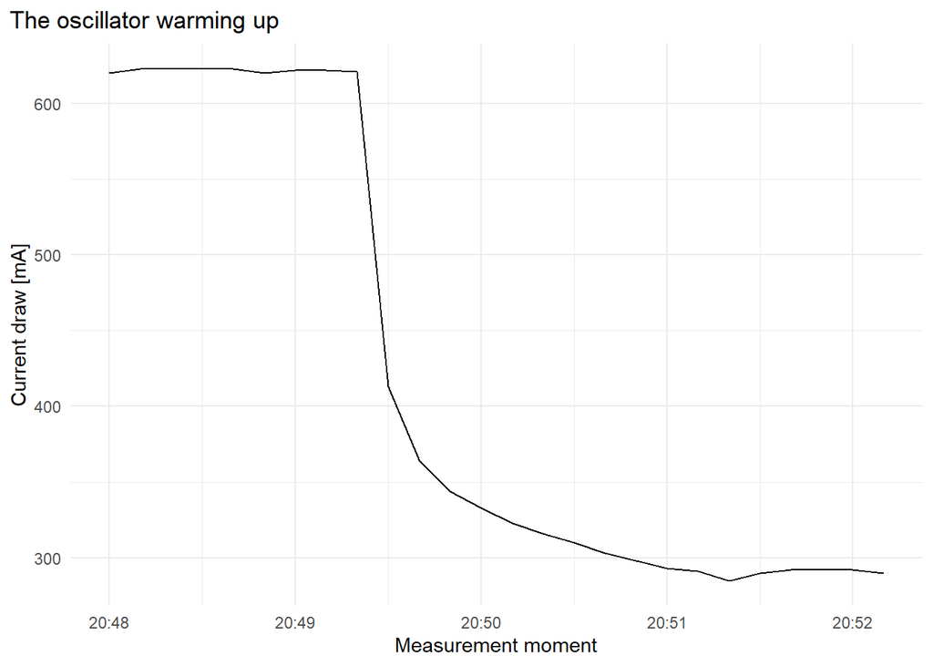

Very slowly, the current draw continued to drop, at 22:20 the current drawn was 236 mA.

# Frequency vs control voltage

If the frequency generated cannot be controlled in a proper window around 10MHz, the oscillator might be too old and for use. I measured the frequency generated for some control voltages, and this doesn’t seem like a problem.

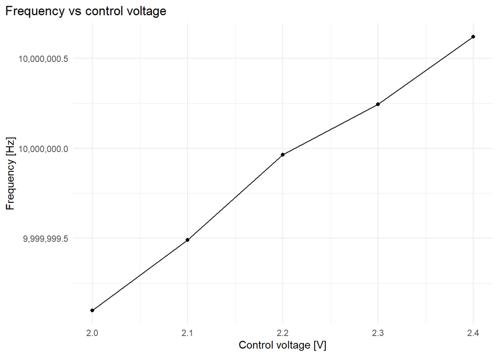

The frequency was measured by my Agilent 53131A with a GPSDO reference (with a 1s gate time). This seems fairly linear, with about 3.8 Hz/V. The potentiometer on the board has 4.096V from the voltage reference over 23 turns, so this will give about 0.68 Hz/turn which should make it possible to calibrate it fairly precisely.

# Amplitude

Running freely, without a load, I measured 2.3V peak-to-peak. With the filtration and the 50 Ohm on-board load resistor that I have adopted from previous designs I measure around 1V peak-to-peak, which is more or less in line with a 50 Ohm internal impedance of the oscillator, and a small insertion loss of the low pass filter I added.